[figure not shown]

# Lung Cancer Survival Analysis and Prediction

### Submitted By:

**Ankasandra Naveen Kumar Karthik & Anusha Reddy Dasari**

### Class:

**ALY 6015 Intermediate Analysis**

### Professor:

**Mohsen Bahrami**

### Date:

**October 15, 2024**

# Introduction

Lung cancer remains one of the most significant health challenges globally, with high mortality rates due to late-stage detection and the complex interactions between multiple clinical, lifestyle, and demographic factors. The goal of this project is to explore the factors that may influence lung cancer survival and develop predictive models that forecast long-term survival in lung cancer patients based on various attributes such as age, tumor size, smoking history, and biomedical markers. Predicting the likelihood of survival can assist healthcare providers in making more informed decisions regarding treatment strategies and patient management.

### Research Questions

1. **Can we predict whether a lung cancer patient will survive more than 60 months using logistic regression based on factors such as age, tumor size, smoking history, and biomedical markers?**

   This question aims to assess whether a combination of demographic, clinical, and lifestyle factors can provide insight into the long-term survival chances of lung cancer patients. By using logistic regression and other regularization techniques, the goal is to build a predictive model that classifies patients into those likely to survive beyond five years and those who are not.
2. **Is there a statistically significant difference in survival time across different treatment types (e.g., surgery, chemotherapy, radiation therapy)?**

   Understanding whether certain treatments are associated with better survival outcomes is crucial in optimizing treatment plans for lung cancer patients. A comparative analysis of treatment types using statistical tests will help determine if specific treatments have a significant impact on survival duration.

### Importance of the Study

Predicting lung cancer survival can significantly enhance patient care by enabling personalized treatment plans and more informed clinical decisions. A reliable survival prediction model can help optimize resource allocation, guide treatment strategies, and improve patient counseling by providing a clearer prognosis. Additionally, understanding the impact of various treatments on survival can lead to better-informed therapeutic choices, ultimately improving outcomes for lung cancer patients.

## Methods

To address the research questions and build predictive models for lung cancer survival, the following steps and techniques were employed:

### 1. Data Collection and Preparation

The lung cancer dataset was loaded and cleaned using the **dplyr** and **janitor** libraries in R. Relevant features were selected, including demographic variables (e.g., age, gender, ethnicity), clinical information (e.g., tumor size, cancer stage, comorbidities), and biomedical markers (e.g., hemoglobin level, glucose level). Categorical variables were converted to factors for proper analysis, while numeric columns were ensured to be treated as numeric data types.

### 2. Exploratory Data Analysis (EDA)

Several visualizations were created to explore the relationships between key variables:

- **Bar Plot**: Tumor location by cancer stage.
- **Boxplot**: Hemoglobin levels by treatment type.
- **Scatter Plot**: Age vs. survival months.
- **Histogram**: Distribution of survival months.

Additionally, a correlation matrix was generated to identify relationships between numeric variables.

### 3. Logistic Regression Modeling

To predict whether a patient will survive more than 60 months, a logistic regression model was built. Features used for modeling included age, tumor size, smoking history, and biomedical markers (e.g., hemoglobin level, glucose level). The dataset was split into training (70%) and test (30%) sets to evaluate model performance.

### 4. Lasso and Ridge Regularization

To improve model accuracy and reduce overfitting, Lasso (L1) and Ridge (L2) regression techniques were applied. These regularization methods penalize large coefficients, leading to more generalized models. The models were trained and evaluated on the same training and test sets used for logistic regression.

### 5. Statistical Testing for Treatment Comparison

To test whether survival times differ significantly across treatment types (i.e., surgery, chemotherapy, radiation therapy), a Kruskal-Wallis test was performed. This non-parametric test was chosen to determine if there were statistically significant differences in survival across the different treatment groups.

By applying these methods, this study aims to explore and predict lung cancer survival outcomes, as well as assess the effectiveness of various treatment types.

# Data Preparation

The lung cancer dataset was carefully prepared to ensure its suitability for analysis and modeling. The following steps outline the data preparation process:

### 1. Data Cleaning

The dataset was loaded from a CSV file, and column names were standardized to snake_case format using the **janitor** package. This ensured consistency and made the column names easier to reference throughout the analysis.

```r
# Step 1: Load the dataset
lung_cancer_data <- read.csv("lung_cancer_data_1.csv")  # Ensure the file is in the correct directory

# Step 2: Clean column names using janitor to convert to snake_case format
lung_cancer_data <- lung_cancer_data %>%
  clean_names()
```

## 2. Feature Selection

Based on the project requirements, relevant features were selected for the analysis. These included:

- **Demographic Variables**: Age, gender, ethnicity, smoking history, smoking pack years.
- **Clinical Variables**: Tumor size, cancer stage, tumor location, and comorbidities (diabetes, hypertension, heart disease, etc.).
- **Biomedical Markers**: Hemoglobin level, white blood cell count, albumin level, LDH level, glucose level.
- **Outcome Variable**: Survival months.

This selection of variables ensures the analysis focuses on the most important factors influencing lung cancer survival.

```r
# Step 3: Select relevant columns based on project requirements
selected_data <- lung_cancer_data %>%
  select(
    age, gender, ethnicity,
    smoking_history, smoking_pack_years,
    tumor_size_mm, stage, tumor_location,
    comorbidity_diabetes, comorbidity_hypertension, comorbidity_heart_disease,
    comorbidity_chronic_lung_disease, comorbidity_kidney_disease, comorbidity_autoimmune_disease,
    treatment,
    hemoglobin_level, white_blood_cell_count, albumin_level,
    ldh_level, glucose_level,
    survival_months
  )
```

## 3. Data Transformation

To facilitate proper analysis and modeling, the following transformations were applied:

- **Categorical Variables**: Variables such as gender, ethnicity, smoking history, cancer stage, tumor location, and comorbidities were converted into factors to ensure correct treatment during statistical analysis.
- **Numeric Variables**: Variables such as age, smoking pack years, tumor size, and biomedical markers were confirmed to be numeric data types to ensure accurate calculations and modeling.

```r
# Step 4: Convert categorical columns to factors for proper analysis
selected_data <- selected_data %>%
  mutate(
    gender = as.factor(gender),
    ethnicity = as.factor(ethnicity),
    smoking_history = as.factor(smoking_history),
    stage = as.factor(stage),
    tumor_location = as.factor(tumor_location),
    comorbidity_diabetes = as.factor(comorbidity_diabetes),
    comorbidity_hypertension = as.factor(comorbidity_hypertension),
    comorbidity_heart_disease = as.factor(comorbidity_heart_disease),
    comorbidity_chronic_lung_disease = as.factor(comorbidity_chronic_lung_disease),
    comorbidity_kidney_disease = as.factor(comorbidity_kidney_disease),
    comorbidity_autoimmune_disease = as.factor(comorbidity_autoimmune_disease),
    treatment = as.factor(treatment)
  )

# Step 5: Ensure numeric columns are treated correctly as numeric data types
selected_data <- selected_data %>%
  mutate(
    age = as.numeric(age),
    smoking_pack_years = as.numeric(smoking_pack_years),
    tumor_size_mm = as.numeric(tumor_size_mm),
    hemoglobin_level = as.numeric(hemoglobin_level),
    white_blood_cell_count = as.numeric(white_blood_cell_count),
    albumin_level = as.numeric(albumin_level),
    ldh_level = as.numeric(ldh_level),
    glucose_level = as.numeric(glucose_level),
    survival_months = as.numeric(survival_months)
  )
```

## 4. Missing Values Check

A check for missing values was conducted across all selected columns to identify any gaps in the data. The number of missing values for each column was recorded, and appropriate handling methods (such as removal or imputation) were applied when necessary.

```r
# Step 6: Check for missing values
missing_values <- colSums(is.na(selected_data))
cat("Missing Values per Column:\n")
```

```
## Missing Values per Column:
```

```r
print(missing_values)
```

```
##                              age                           gender
##                                0                                0
##                        ethnicity                  smoking_history
##                                0                                0
##               smoking_pack_years                    tumor_size_mm
##                                0                                0
##                            stage                   tumor_location
##                                0                                0
##             comorbidity_diabetes         comorbidity_hypertension
##                                0                                0
##        comorbidity_heart_disease comorbidity_chronic_lung_disease
##                                0                                0
##       comorbidity_kidney_disease   comorbidity_autoimmune_disease
##                                0                                0
##                        treatment                 hemoglobin_level
##                                0                                0
##           white_blood_cell_count                    albumin_level
##                                0                                0
##                        ldh_level                    glucose_level
##                                0                                0
##                  survival_months
##                                0
```

## 5. Filtering of Data

The dataset was filtered to include only patients aged between 18 and 60 years, with positive survival months. This helped focus the analysis on the most relevant patient group and excluded extreme or irrelevant data points that could skew the results.

```r
# Step 7: Filter dataset for patients aged between 18 and 60 with positive survival months
selected_data <- selected_data %>%
  filter(age >= 18 & age <= 60, survival_months > 0)
```

# Exploratory Data Analysis (EDA)

Several visualizations were created to explore relationships between the variables:

## a. Tumor Location by Cancer Stage Chart

The bar chart shows the distribution of tumor locations (lower lobe, middle lobe, upper lobe) across different cancer stages (Stage I to Stage IV). Each tumor location is evenly distributed across the stages, indicating no significant variation in tumor placement by stage.

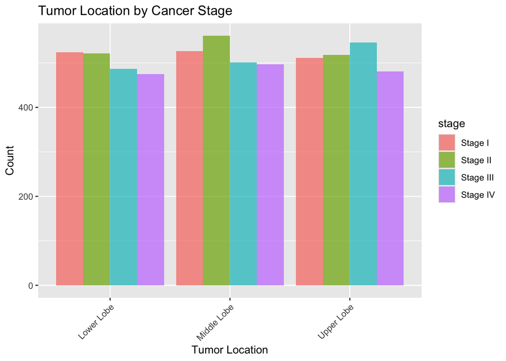

### Interpretation

Tumor location does not show a significant association with cancer stage, as the distribution remains consistent across different stages. This indicates that tumor location alone may not be a major determinant of cancer progression. Instead, other factors like tumor size, treatment type, and patient health likely play a more important role in influencing survival and treatment outcomes.

## b. Hemoglobin Levels by Treatment Type Chart

The box plot shows the distribution of hemoglobin levels across different treatment types: Chemotherapy, Radiation Therapy, Surgery, and Targeted Therapy.

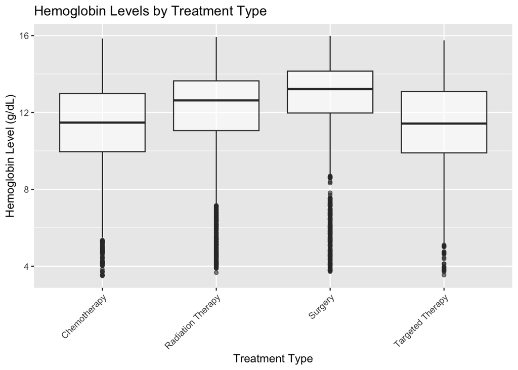

## c. Age vs. Survival Months Chart

This scatter plot visualizes the relationship between age and survival months, with each point representing a patient. The red line represents the overall trend in survival months across different ages.

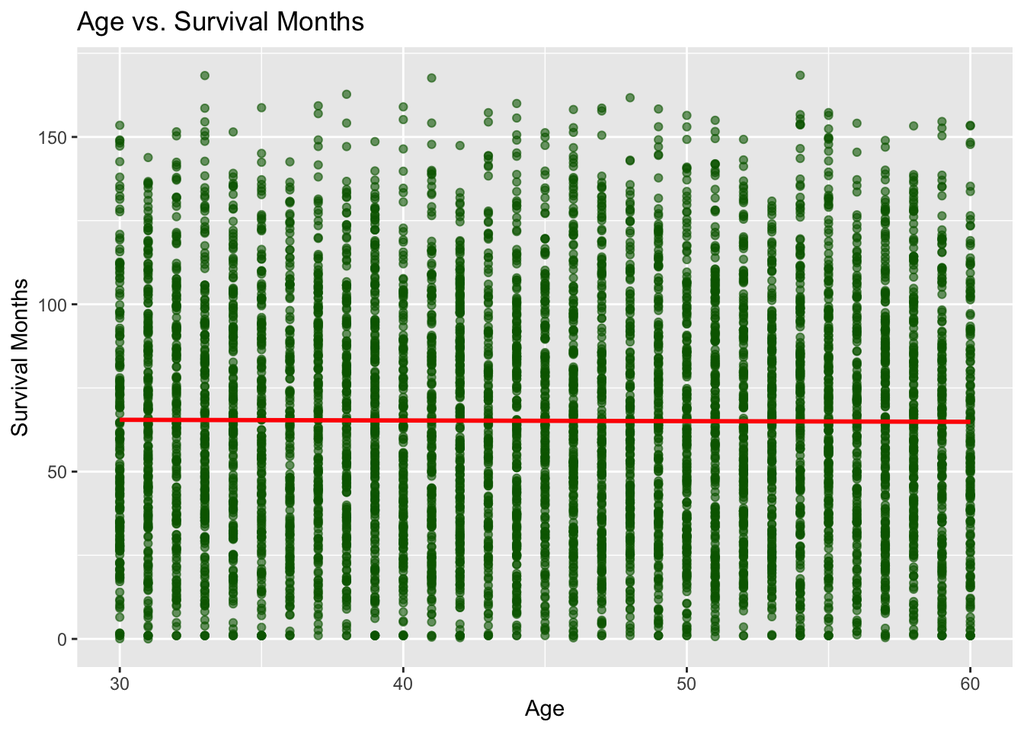

### Interpretation

The chart shows no clear trend between age and survival months, with the red line being relatively flat. This indicates that age does not have a strong influence on survival time in this dataset. Patients of varying ages appear to have similar survival outcomes, suggesting other factors, such as treatment type or tumor size, may play a more significant role in determining survival duration.

## d. Distribution of Survival Months Chart

This histogram displays the distribution of survival months for patients, indicating the frequency of survival durations in the dataset.

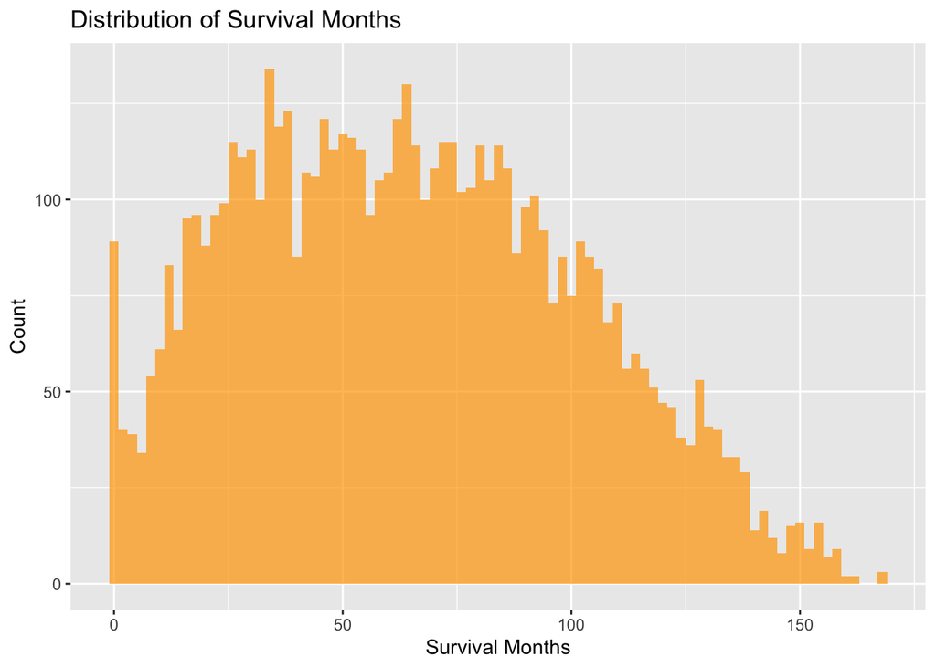

## e. Correlation Matrix Chart

The correlation matrix displays the relationships between numeric variables such as tumor size, survival months, and biochemical markers (e.g., hemoglobin, glucose levels). The color intensity and size of the circles indicate the strength and direction of the correlations.

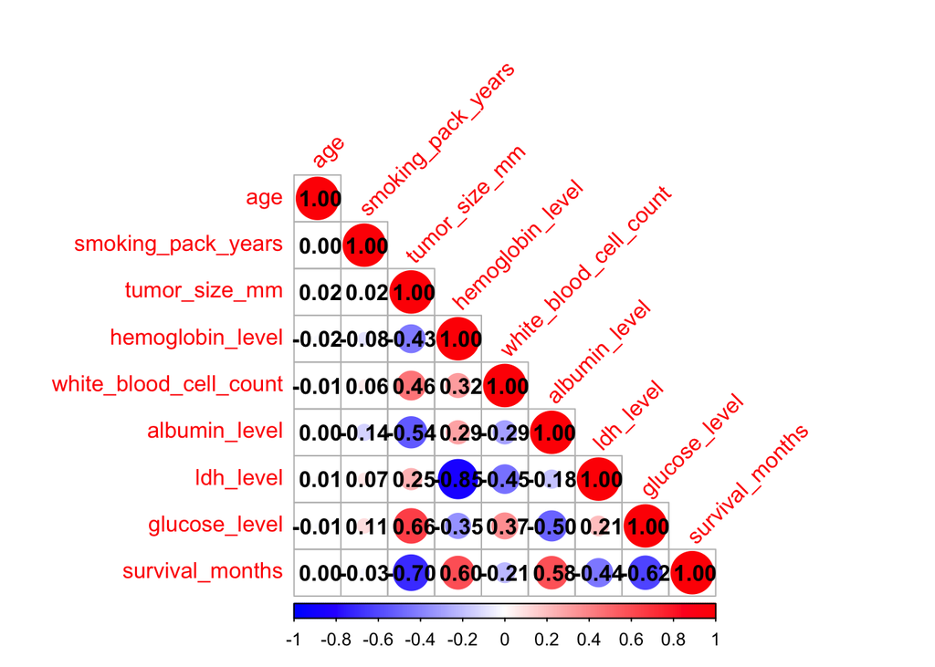

# Analysis

### Research Question 1:

Can we predict a lung cancer patient will survive more than 60 months using logistic regression based on the features like age, tumor size, smoking history, and biomedical markers?

This section outlines the results of predictive modeling efforts aimed at answering the research question. Three logistic regression models were built: a basic logistic regression, Lasso regularization, and Ridge regularization. These models were evaluated to predict whether a patient survives more than 60 months based on selected features such as age, tumor size, smoking history, and biomedical markers. The dataset was split into a training set (70%) and a test set (30%) to assess generalization.

### 1. Binary Outcome Variable

A binary outcome variable was created to represent survival beyond 60 months. Patients with survival months greater than 60 were coded as `1`, while those with survival months less than or equal to 60 were coded as `0`.

```r
# Step 9: Create a binary outcome variable for survival beyond 60 months
selected_data$survived_60_months <- ifelse(selected_data$survival_months > 60, 1, 0)
```

### 2. Feature Selection & Data Split

The logistic regression models were built using the following features:

- Age
- Tumor size (in millimeters)
- Smoking pack years
- Hemoglobin level
- White blood cell count
- Albumin level
- LDH level
- Glucose level

These features were identified based on their relevance in predicting long-term survival in lung cancer patients.

```r
# Step 10: Select relevant features for logistic regression modeling
features <- c("age", "tumor_size_mm", "smoking_pack_years", "hemoglobin_level",
              "white_blood_cell_count", "albumin_level", "ldh_level",
              "glucose_level")

# Step 11: Prepare data for model training
X <- as.matrix(selected_data[, features])
y <- selected_data$survived_60_months

# Split the dataset into training (70%) and test (30%) sets
set.seed(42)  # For reproducibility
train_index <- createDataPartition(y, p = 0.7, list = FALSE)
X_train <- X[train_index, ]
X_test <- X[-train_index, ]
y_train <- y[train_index]
y_test <- y[-train_index]
```

### 3. Basic Logistic Regression

The first model built was a basic logistic regression, which served as the baseline for comparison. The model’s performance was assessed using the following metrics:

- **Accuracy**: The overall correctness of the model.
- **Sensitivity**: The model’s ability to correctly identify patients who survived less than or equal to 60 months.
- **Specificity**: The model’s ability to correctly identify patients who survived more than 60 months.
- **ROC Curve**: The ROC curve for the basic logistic regression was plotted to measure its discriminative ability between the two survival categories.

A confusion matrix was generated to further evaluate the performance of the basic logistic regression model.

```r
# Step 12: Basic Logistic Regression (without regularization)
basic_glm <- glm(survived_60_months ~ ., data = selected_data[train_index, c(features, "survived_60_months")], family = binomial)
basic_glm_predictions <- predict(basic_glm, newdata = selected_data[-train_index, c(features, "survived_60_months")], type = "response")
basic_glm_pred_class <- ifelse(basic_glm_predictions > 0.5, 1, 0)

# Evaluate and visualize the basic logistic regression model
cat("Basic GLM Performance:\n")
```

```
## Basic GLM Performance:
```

```r
print(confusionMatrix(as.factor(basic_glm_pred_class), as.factor(y_test)))
```

```
## Confusion Matrix and Statistics
##
##           Reference
## Prediction   0   1
##          0 719 134
##          1 170 821
##
##                Accuracy : 0.8351
##                  95% CI : (0.8174, 0.8518)
##     No Information Rate : 0.5179
##     P-Value [Acc > NIR] : < 0.0000000000000002
##
##                   Kappa : 0.6694
##
##  Mcnemar's Test P-Value : 0.04471
##
##             Sensitivity : 0.8088
##             Specificity : 0.8597
##          Pos Pred Value : 0.8429
##          Neg Pred Value : 0.8285
##              Prevalence : 0.4821
##          Detection Rate : 0.3899
##    Detection Prevalence : 0.4626
##       Balanced Accuracy : 0.8342
##
##        'Positive' Class : 0
##
```

### 4. Lasso (L1) Regularization

Lasso regularization was applied to improve the model by shrinking some coefficients to zero, thereby selecting only the most relevant features. Two versions of the Lasso model were evaluated:

- **Lasso with lambda.min**: The lambda value that minimizes cross-validation error.
- **Lasso with lambda.1se**: The largest lambda value within one standard error of the minimum.

The performance of both Lasso models was assessed using the same metrics as the basic logistic regression:

- Accuracy
- Sensitivity
- Specificity
- ROC curves

Additionally, confusion matrix heatmaps were created to visualize model performance and classification accuracy.

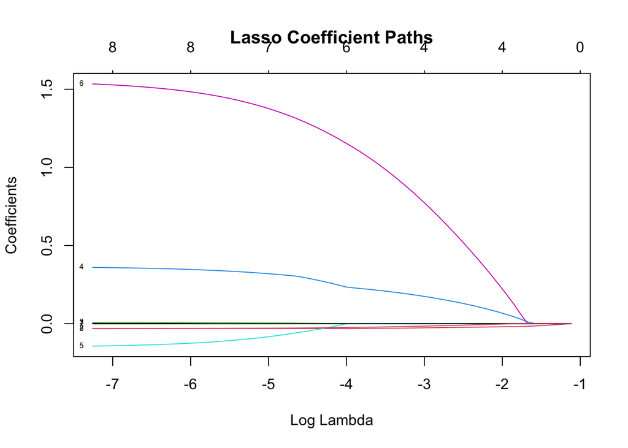

```r
# Step 13: Lasso (L1) Regularization Logistic Regression
lasso_model <- cv.glmnet(X_train, y_train, family = "binomial", alpha = 1)

# Predictions for Lasso with lambda.min and lambda.1se
lasso_predictions_min <- predict(lasso_model, newx = X_test, s = "lambda.min", type = "class")
lasso_predictions_1se <- predict(lasso_model, newx = X_test, s = "lambda.1se", type = "class")
lasso_pred_class_min <- ifelse(lasso_predictions_min > 0.5, 1, 0)
lasso_pred_class_1se <- ifelse(lasso_predictions_1se > 0.5, 1, 0)

# Visualize Lasso coefficient paths
plot(lasso_model$glmnet.fit, xvar = "lambda", label = TRUE, main = "Lasso Coefficient Paths")
```

```r
# Evaluate and visualize the Lasso model for lambda.min
cat("Lasso (L1) Performance with lambda.min:\n")
```

```
## Lasso (L1) Performance with lambda.min:
```

```r
print(confusionMatrix(as.factor(lasso_pred_class_min), as.factor(y_test)))
```

```
## Confusion Matrix and Statistics
##
##           Reference
## Prediction   0   1
##          0 717 135
##          1 172 820
##
##                Accuracy : 0.8335
##                  95% CI : (0.8157, 0.8502)
##     No Information Rate : 0.5179
##     P-Value [Acc > NIR] : < 0.0000000000000002
##
##                   Kappa : 0.6661
##
##  Mcnemar's Test P-Value : 0.03991
##
##             Sensitivity : 0.8065
##             Specificity : 0.8586
##          Pos Pred Value : 0.8415
##          Neg Pred Value : 0.8266
##              Prevalence : 0.4821
##          Detection Rate : 0.3888
##    Detection Prevalence : 0.4620
##       Balanced Accuracy : 0.8326
##
##        'Positive' Class : 0
##
```

```r
# Evaluate and visualize the Lasso model for lambda.1se
cat("Lasso (L1) Performance with lambda.1se:\n")
```

```
## Lasso (L1) Performance with lambda.1se:
```

```r
print(confusionMatrix(as.factor(lasso_pred_class_1se), as.factor(y_test)))
```

```
## Confusion Matrix and Statistics
##
##           Reference
## Prediction   0   1
##          0 724 146
##          1 165 809
##
##                Accuracy : 0.8313
##                  95% CI : (0.8135, 0.8482)
##     No Information Rate : 0.5179
##     P-Value [Acc > NIR] : <0.0000000000000002
##
##                   Kappa : 0.662
##
##  Mcnemar's Test P-Value : 0.3074
##
##             Sensitivity : 0.8144
##             Specificity : 0.8471
##          Pos Pred Value : 0.8322
##          Neg Pred Value : 0.8306
##              Prevalence : 0.4821
##          Detection Rate : 0.3926
##    Detection Prevalence : 0.4718
##       Balanced Accuracy : 0.8308
##
##        'Positive' Class : 0
##
```

### 5. Ridge (L2) Regularization

Ridge regularization was also used, where all features are retained but their coefficients are penalized to reduce overfitting. Similar to Lasso, two versions of the Ridge model were evaluated:

- **Ridge with lambda.min**: The lambda value that minimizes cross-validation error.
- **Ridge with lambda.1se**: The largest lambda value within one standard error of the minimum.

The Ridge model’s performance was evaluated using accuracy, sensitivity, specificity, ROC curves, and confusion matrix heatmaps.

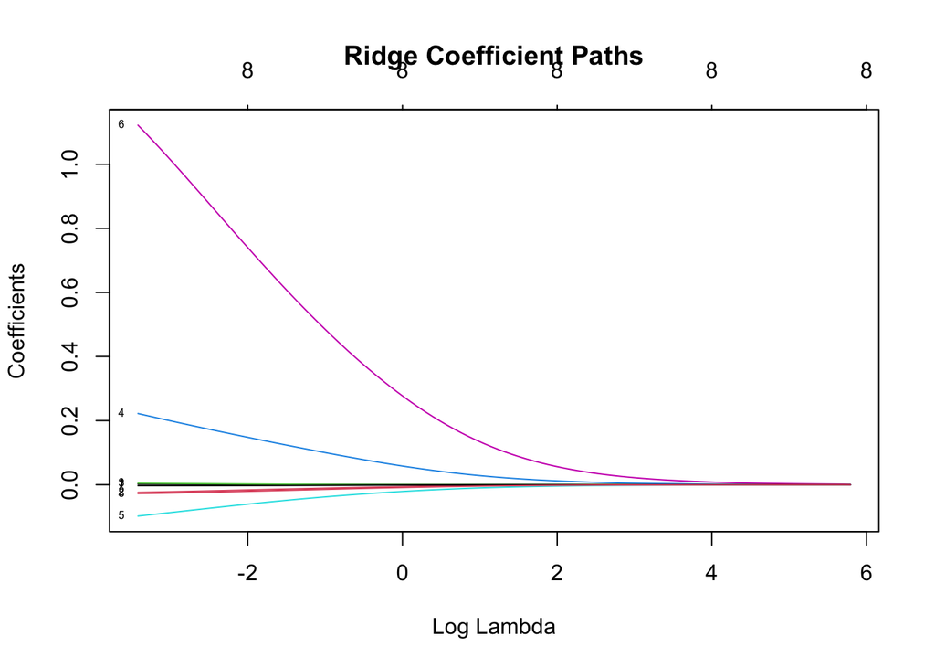

```r
# Step 14: Ridge (L2) Regularization Logistic Regression
ridge_model <- cv.glmnet(X_train, y_train, family = "binomial", alpha = 0)

# Predictions for Ridge with lambda.min and lambda.1se
ridge_predictions_min <- predict(ridge_model, newx = X_test, s = "lambda.min", type = "class")
ridge_predictions_1se <- predict(ridge_model, newx = X_test, s = "lambda.1se", type = "class")
ridge_pred_class_min <- ifelse(ridge_predictions_min > 0.5, 1, 0)
ridge_pred_class_1se <- ifelse(ridge_predictions_1se > 0.5, 1, 0)

# Visualize Ridge coefficient paths
plot(ridge_model$glmnet.fit, xvar = "lambda", label = TRUE, main = "Ridge Coefficient Paths")
```

```r
# Evaluate and visualize the Ridge model for lambda.min
cat("Ridge (L2) Performance with lambda.min:\n")
```

```
## Ridge (L2) Performance with lambda.min:
```

```r
print(confusionMatrix(as.factor(ridge_pred_class_min), as.factor(y_test)))
```

```
## Confusion Matrix and Statistics
##
##           Reference
## Prediction   0   1
##          0 719 138
##          1 170 817
##
##                Accuracy : 0.833
##                  95% CI : (0.8151, 0.8497)
##     No Information Rate : 0.5179
##     P-Value [Acc > NIR] : < 0.0000000000000002
##
##                   Kappa : 0.6651
##
##  Mcnemar's Test P-Value : 0.07733
##
##             Sensitivity : 0.8088
##             Specificity : 0.8555
##          Pos Pred Value : 0.8390
##          Neg Pred Value : 0.8278
##              Prevalence : 0.4821
##          Detection Rate : 0.3899
##    Detection Prevalence : 0.4648
##       Balanced Accuracy : 0.8321
##
##        'Positive' Class : 0
##
```

```r
# Evaluate and visualize the Ridge model for lambda.1se
cat("Ridge (L2) Performance with lambda.1se:\n")
```

```
## Ridge (L2) Performance with lambda.1se:
```

```r
print(confusionMatrix(as.factor(ridge_pred_class_1se), as.factor(y_test)))
```

```
## Confusion Matrix and Statistics
##
##           Reference
## Prediction   0   1
##          0 721 137
##          1 168 818
##
##                Accuracy : 0.8346
##                  95% CI : (0.8168, 0.8513)
##     No Information Rate : 0.5179
##     P-Value [Acc > NIR] : < 0.0000000000000002
##
##                   Kappa : 0.6684
##
##  Mcnemar's Test P-Value : 0.08583
##
##             Sensitivity : 0.8110
##             Specificity : 0.8565
##          Pos Pred Value : 0.8403
##          Neg Pred Value : 0.8296
##              Prevalence : 0.4821
##          Detection Rate : 0.3910
##    Detection Prevalence : 0.4653
##       Balanced Accuracy : 0.8338
##
##        'Positive' Class : 0
##
```

### 7. Visualizations

Several visualizations were generated for each model:

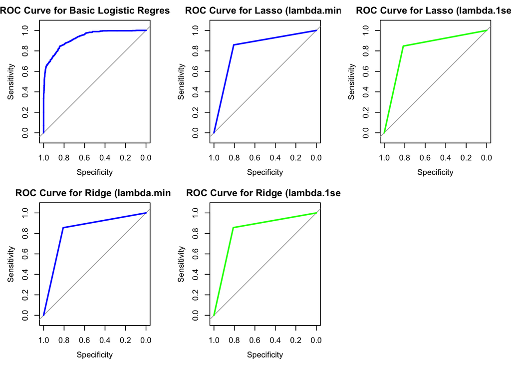

- **Confusion Matrix Heatmaps**: Heatmaps were created for each model to display classification accuracy, highlighting areas of correct and incorrect predictions.

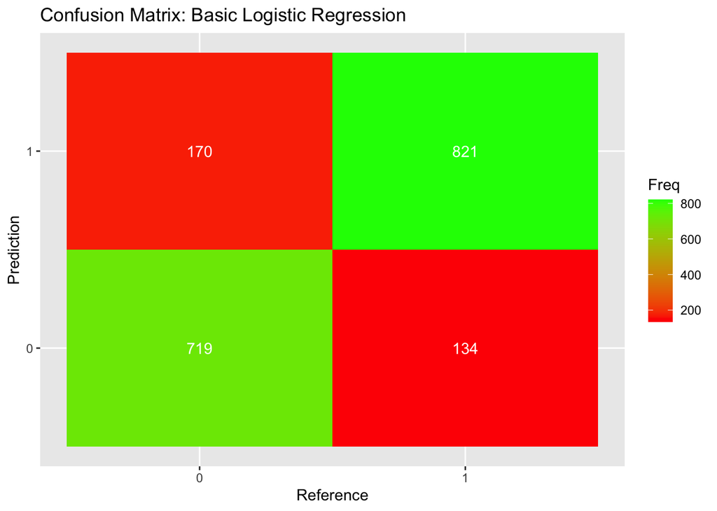

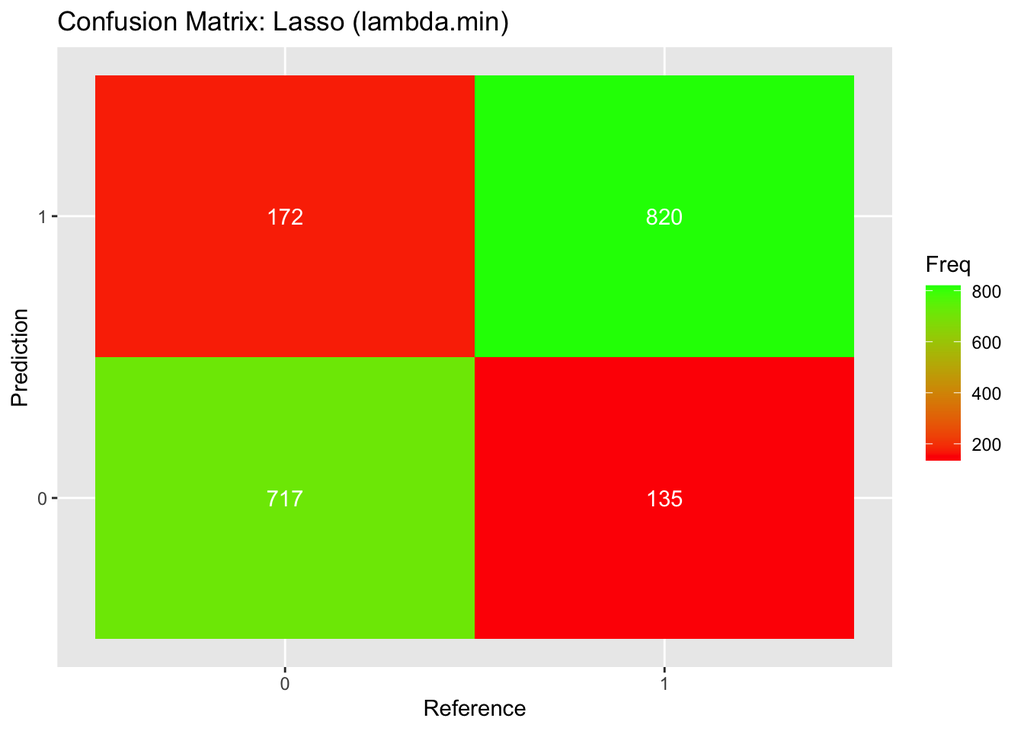

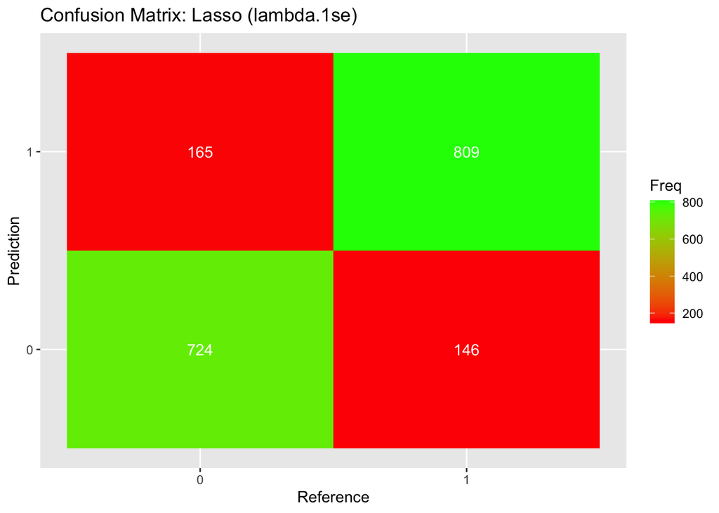

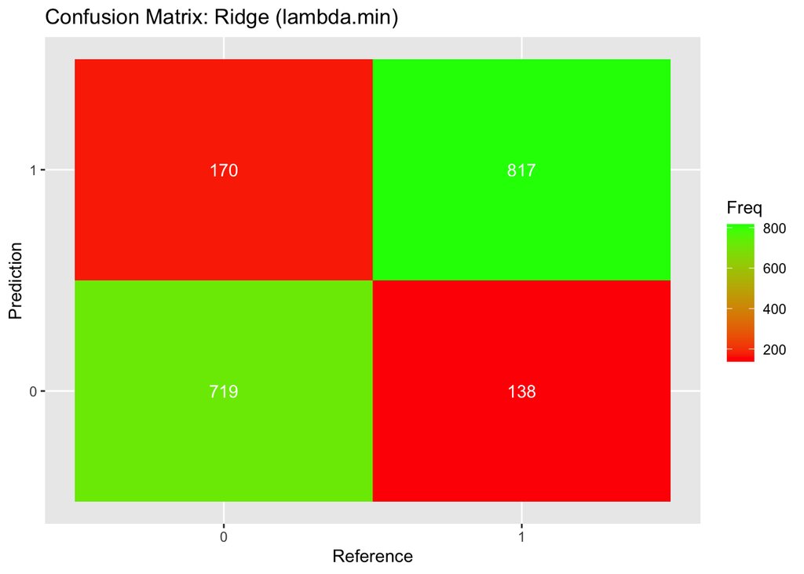

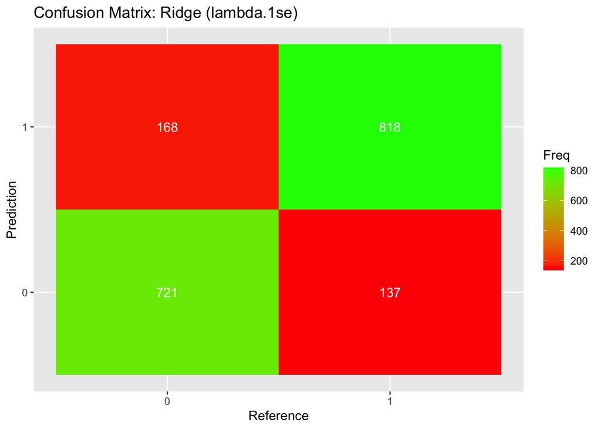

### 8. Question 1 Conclusion

- **Basic logistic regression** served as a strong baseline model.
- **Lasso regularization** helped reduce model complexity by selecting only the most important predictors.
- **Ridge regularization** maintained all predictors but reduced their impact by shrinking coefficients.

These models can provide clinicians with valuable insights into patient outcomes and help inform personalized treatment plans for lung cancer patients.

### Research Question 2

Is there a statistically significant difference in survival time across different treatment types (e.g., Surgery, Chemotherapy, Radiation Therapy)?

### Step 1: Distribution of Treatment Types

The distribution of the `treatment` variable within the dataset was examined to provide context for the analysis. The distribution of treatment types is as follows:

```r
# Step 1: Check the distribution of 'treatment' variable
cat("Distribution of treatment types:\n")
```

```
## Distribution of treatment types:
```

```r
print(table(selected_data$treatment))
```

```
##
##      Chemotherapy Radiation Therapy           Surgery  Targeted Therapy
##              1917              1835              1590               806
```

This table highlights the number of patients receiving each treatment type, which is important for ensuring the robustness of statistical comparisons.

### Step 2: Kruskal-Wallis Test

The Kruskal-Wallis test was applied to compare survival times across treatment types, as the data on survival months did not meet the assumptions required for parametric tests. This non-parametric test is appropriate when the data are not normally distributed or when dealing with ordinal data.

```r
# Step 2: Perform Kruskal-Wallis Test to compare survival months across treatment types
kruskal_test <- kruskal.test(survival_months ~ treatment, data = selected_data)
```

### Hypotheses

- **Null Hypothesis (H₀)**: There is no difference in the median survival times across the treatment groups.
- **Alternative Hypothesis (H₁)**: There is a statistically significant difference in the median survival times across at least two of the treatment groups.

### Step 3: Kruskal-Wallis Test Results

The results of the Kruskal-Wallis test are presented below:

```r
# Step 3: Output the result of the Kruskal-Wallis test
cat("Kruskal-Wallis Test Results:\n")
```

```
## Kruskal-Wallis Test Results:
```

```r
print(kruskal_test)
```

```
##
##  Kruskal-Wallis rank sum test
##
## data:  survival_months by treatment
## Kruskal-Wallis chi-squared = 801.93, df = 3, p-value <
## 0.00000000000000022
```

- **Test Statistic**: $\chi^2 = 801.93$
- **Degrees of Freedom (df)**: 3
- **p-value**: < 0.00000000000000022

The p-value is significantly below the conventional threshold of 0.05, which allows for rejection of the null hypothesis. This indicates a statistically significant difference in median survival times across the treatment groups, suggesting that the type of treatment received influences survival outcomes.

### Step 4: Visualizing Survival Time by Treatment Type

To visualize the differences in survival times among treatment types, boxplots were created. These boxplots depict the distribution of survival times for each treatment group, illustrating the median, interquartile range (IQR), and potential outliers.

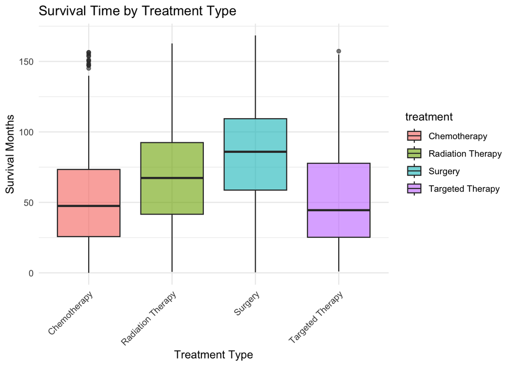

This visualization aids in identifying trends and differences in survival times among treatment types. For instance, one treatment may have a higher median survival time compared to others, suggesting its potential effectiveness.

### Question 2 Conclusion

The Kruskal-Wallis test revealed a statistically significant difference in survival times across the treatment types. This finding implies that the type of treatment received plays a critical role in influencing survival outcomes for lung cancer patients. The boxplots further support these results, providing a visual representation of how treatment choice impacts survival.

These findings can help healthcare professionals evaluate the effectiveness of different treatments and make more informed decisions aimed at improving patient survival.

# Conclusion

This project involved a comprehensive analysis of lung cancer survival using predictive modeling techniques. The primary objective was to identify the factors influencing long-term survival in lung cancer patients and to develop reliable models to predict survival outcomes based on various clinical and demographic attributes.

In addition, the analysis of treatment modalities revealed a statistically significant difference in median survival times across treatment types, as determined by the Kruskal-Wallis test. This finding indicates that treatment choice plays a crucial role in patient outcomes, underscoring the importance of personalized treatment strategies based on individual patient profiles.

The integration of these predictive models into clinical practice has the potential to enhance patient care by informing treatment decisions and improving survival outcomes. By leveraging data-driven insights, healthcare providers can develop tailored interventions that consider each patient’s unique circumstances.

Overall, this project highlights the importance of data analysis in understanding complex health issues such as lung cancer. Future research could further refine these models by incorporating additional variables, exploring machine learning approaches, and validating findings across diverse patient populations. This work lays the foundation for ongoing efforts to improve survival rates and quality of life for lung cancer patients.

# References

- Hosmer, D. W., Lemeshow, S., & Sturdivant, R. X. (2013). *Applied logistic regression* (3rd ed.). John Wiley & Sons.
- Kleinbaum, D. G., & Klein, M. (2012). *Survival analysis: A self-learning text* (3rd ed.). Springer.
- Harrell, F. E. (2015). *Regression modeling strategies: With applications to linear models, logistic and ordinal regression, and survival analysis* (2nd ed.). Springer.
- Mammadov, R. (2024). *Lung cancer prediction*. Kaggle.com. https://www.kaggle.com/datasets/rashadrmammadov/lung-cancer-prediction

# Appendix

```r
# Name: Ankasandra Naveen Kumar Karthik & Anusha Reddy Dasari
# Class: ALY6015 Intermediate Analysis
# Date: 10/15/2024

# Clear the environment, console, and plots
rm(list = ls())  # Clear all objects from the global environment
try(dev.off(dev.list()["RStudioGD"]), silent = TRUE)  # Clear all plots
options(scipen = 100)  # Disable scientific notation for readability
cat("\014")  # Clear the console

# Load necessary libraries for data manipulation, visualization, and modeling
library(dplyr)        # For data manipulation
library(ggplot2)      # For visualizations
library(janitor)      # For cleaning column names
library(corrplot)     # For correlation matrix visualization
library(glmnet)       # For Lasso and Ridge regression
library(caret)        # For data partitioning and model evaluation
library(pROC)         # For plotting ROC curves

# Step 1: Load the dataset
lung_cancer_data <- read.csv("lung_cancer_data_1.csv")  # Ensure the file is in the correct directory

# Step 2: Clean column names using janitor to convert to snake_case format
lung_cancer_data <- lung_cancer_data %>%
  clean_names()

# Step 3: Select relevant columns based on project requirements
selected_data <- lung_cancer_data %>%
  select(
    age, gender, ethnicity,
    smoking_history, smoking_pack_years,
    tumor_size_mm, stage, tumor_location,
    comorbidity_diabetes, comorbidity_hypertension, comorbidity_heart_disease,
    comorbidity_chronic_lung_disease, comorbidity_kidney_disease, comorbidity_autoimmune_disease,
    treatment,
    hemoglobin_level, white_blood_cell_count, albumin_level,
    ldh_level, glucose_level,
    survival_months
  )

# Step 4: Convert categorical columns to factors for proper analysis
selected_data <- selected_data %>%
  mutate(
    gender = as.factor(gender),
    ethnicity = as.factor(ethnicity),
    smoking_history = as.factor(smoking_history),
    stage = as.factor(stage),
    tumor_location = as.factor(tumor_location),
    comorbidity_diabetes = as.factor(comorbidity_diabetes),
    comorbidity_hypertension = as.factor(comorbidity_hypertension),
    comorbidity_heart_disease = as.factor(comorbidity_heart_disease),
    comorbidity_chronic_lung_disease = as.factor(comorbidity_chronic_lung_disease),
    comorbidity_kidney_disease = as.factor(comorbidity_kidney_disease),
    comorbidity_autoimmune_disease = as.factor(comorbidity_autoimmune_disease),
    treatment = as.factor(treatment)
  )

# Step 5: Ensure numeric columns are treated correctly as numeric data types
selected_data <- selected_data %>%
  mutate(
    age = as.numeric(age),
    smoking_pack_years = as.numeric(smoking_pack_years),
    tumor_size_mm = as.numeric(tumor_size_mm),
    hemoglobin_level = as.numeric(hemoglobin_level),
    white_blood_cell_count = as.numeric(white_blood_cell_count),
    albumin_level = as.numeric(albumin_level),
    ldh_level = as.numeric(ldh_level),
    glucose_level = as.numeric(glucose_level),
    survival_months = as.numeric(survival_months)
  )

# Step 6: Check for missing values
missing_values <- colSums(is.na(selected_data))
cat("Missing Values per Column:\n")
print(missing_values)

# Step 7: Filter dataset for patients aged between 18 and 60 with positive survival months
selected_data <- selected_data %>%
  filter(age >= 18 & age <= 60, survival_months > 0)

# Step 8: Exploratory Data Analysis (EDA)

# 1. Bar plot: Tumor Location by Cancer Stage
ggplot(selected_data, aes(x = tumor_location, fill = stage)) +
  geom_bar(position = "dodge", alpha = 0.7) +
  labs(title = "Tumor Location by Cancer Stage", x = "Tumor Location", y = "Count") +
  theme(axis.text.x = element_text(angle = 45, hjust = 1))

# 2. Boxplot: Hemoglobin Levels by Treatment Type
ggplot(selected_data, aes(x = treatment, y = hemoglobin_level)) +
  geom_boxplot(alpha = 0.6) +
  labs(title = "Hemoglobin Levels by Treatment Type", x = "Treatment Type", y = "Hemoglobin Level (g/dL)") +
  theme(axis.text.x = element_text(angle = 45, hjust = 1))

# 3. Scatter plot: Age vs Survival Months with trend line
ggplot(selected_data, aes(x = age, y = survival_months)) +
  geom_point(color = "darkgreen", alpha = 0.6) +
  labs(title = "Age vs. Survival Months", x = "Age", y = "Survival Months") +
  geom_smooth(method = "lm", se = FALSE, color = "red")

# 4. Histogram: Distribution of Survival Months
ggplot(selected_data, aes(x = survival_months)) +
  geom_histogram(binwidth = 2, fill = "orange", alpha = 0.7) +
  labs(title = "Distribution of Survival Months", x = "Survival Months", y = "Count")

# 5. Correlation matrix for numeric variables
numeric_data <- selected_data %>% select(where(is.numeric))
correlation_matrix <- cor(numeric_data, use = "complete.obs")
corrplot(correlation_matrix, method = "circle", type = "lower", addCoef.col = "black",
         tl.col = "red", tl.srt = 45, col = colorRampPalette(c("blue", "white", "red"))(200))

# Research Question :
## Can we predit a lung cancer patient will survive more than 60 months using logistic regression based on the features like (age,tumor_size,smoking_history and bio-medical markers)?

# Step 9: Create a binary outcome variable for survival beyond 60 months
selected_data$survived_60_months <- ifelse(selected_data$survival_months > 60, 1, 0)

# Step 10: Select relevant features for logistic regression modeling
features <- c("age", "tumor_size_mm", "smoking_pack_years", "hemoglobin_level",
              "white_blood_cell_count", "albumin_level", "ldh_level",
              "glucose_level")

# Step 11: Prepare data for model training
X <- as.matrix(selected_data[, features])
y <- selected_data$survived_60_months

# Split the dataset into training (70%) and test (30%) sets
set.seed(42)  # For reproducibility
train_index <- createDataPartition(y, p = 0.7, list = FALSE)
X_train <- X[train_index, ]
X_test <- X[-train_index, ]
y_train <- y[train_index]
y_test <- y[-train_index]

# Step 12: Basic Logistic Regression (without regularization)
basic_glm <- glm(survived_60_months ~ ., data = selected_data[train_index, c(features, "survived_60_months")], family = binomial)
basic_glm_predictions <- predict(basic_glm, newdata = selected_data[-train_index, c(features, "survived_60_months")], type = "response")
basic_glm_pred_class <- ifelse(basic_glm_predictions > 0.5, 1, 0)
```

```r
# Evaluate and visualize the basic logistic regression model
cat("Basic GLM Performance:\n")
print(confusionMatrix(as.factor(basic_glm_pred_class), as.factor(y_test)))

# ROC Curve for Basic Logistic Regression
basic_glm_roc <- roc(y_test, basic_glm_predictions)
plot(basic_glm_roc, col = "blue", lwd = 2, main = "ROC Curve for Basic Logistic Regression")

# Confusion Matrix Heatmap for Basic Logistic Regression
basic_glm_conf_matrix <- confusionMatrix(as.factor(basic_glm_pred_class), as.factor(y_test))
ggplot(data = as.data.frame(basic_glm_conf_matrix$table), aes(x = Reference, y = Prediction, fill = Freq)) +
  geom_tile() +
  geom_text(aes(label = Freq), color = "white") +
  labs(title = "Confusion Matrix: Basic Logistic Regression") +
  scale_fill_gradient(low = "red", high = "green")

# Step 13: Lasso (L1) Regularization Logistic Regression
lasso_model <- cv.glmnet(X_train, y_train, family = "binomial", alpha = 1)

# Predictions for Lasso with lambda.min and lambda.1se
lasso_predictions_min <- predict(lasso_model, newx = X_test, s = "lambda.min", type = "class")
lasso_predictions_1se <- predict(lasso_model, newx = X_test, s = "lambda.1se", type = "class")
lasso_pred_class_min <- ifelse(lasso_predictions_min > 0.5, 1, 0)
lasso_pred_class_1se <- ifelse(lasso_predictions_1se > 0.5, 1, 0)

# Visualize Lasso coefficient paths
plot(lasso_model$glmnet.fit, xvar = "lambda", label = TRUE, main = "Lasso Coefficient Paths")

# Evaluate and visualize the Lasso model for lambda.min
cat("Lasso (L1) Performance with lambda.min:\n")
print(confusionMatrix(as.factor(lasso_pred_class_min), as.factor(y_test)))

# ROC Curve for Lasso (lambda.min)
lasso_roc_min <- roc(y_test, as.numeric(lasso_pred_class_min))
plot(lasso_roc_min, col = "blue", lwd = 2, main = "ROC Curve for Lasso (lambda.min)")

# Confusion Matrix Heatmap for Lasso (lambda.min)
lasso_conf_matrix_min <- confusionMatrix(as.factor(lasso_pred_class_min), as.factor(y_test))
ggplot(data = as.data.frame(lasso_conf_matrix_min$table), aes(x = Reference, y = Prediction, fill = Freq)) +
  geom_tile() +
  geom_text(aes(label = Freq), color = "white") +
  labs(title = "Confusion Matrix: Lasso (lambda.min)") +
  scale_fill_gradient(low = "red", high = "green")

# Evaluate and visualize the Lasso model for lambda.1se
cat("Lasso (L1) Performance with lambda.1se:\n")
print(confusionMatrix(as.factor(lasso_pred_class_1se), as.factor(y_test)))

# ROC Curve for Lasso (lambda.1se)
lasso_roc_1se <- roc(y_test, as.numeric(lasso_pred_class_1se))
plot(lasso_roc_1se, col = "green", lwd = 2, main = "ROC Curve for Lasso (lambda.1se)")

# Confusion Matrix Heatmap for Lasso (lambda.1se)
lasso_conf_matrix_1se <- confusionMatrix(as.factor(lasso_pred_class_1se), as.factor(y_test))
ggplot(data = as.data.frame(lasso_conf_matrix_1se$table), aes(x = Reference, y = Prediction, fill = Freq)) +
  geom_tile() +
  geom_text(aes(label = Freq), color = "white") +
  labs(title = "Confusion Matrix: Lasso (lambda.1se)") +
  scale_fill_gradient(low = "red", high = "green")

# Step 14: Ridge (L2) Regularization Logistic Regression
ridge_model <- cv.glmnet(X_train, y_train, family = "binomial", alpha = 0)

# Predictions for Ridge with lambda.min and lambda.1se
ridge_predictions_min <- predict(ridge_model, newx = X_test, s = "lambda.min", type = "class")
ridge_predictions_1se <- predict(ridge_model, newx = X_test, s = "lambda.1se", type = "class")
ridge_pred_class_min <- ifelse(ridge_predictions_min > 0.5, 1, 0)
ridge_pred_class_1se <- ifelse(ridge_predictions_1se > 0.5, 1, 0)

# Visualize Ridge coefficient paths
plot(ridge_model$glmnet.fit, xvar = "lambda", label = TRUE, main = "Ridge Coefficient Paths")

# Evaluate and visualize the Ridge model for lambda.min
cat("Ridge (L2) Performance with lambda.min:\n")
print(confusionMatrix(as.factor(ridge_pred_class_min), as.factor(y_test)))

# ROC Curve for Ridge (lambda.min)
ridge_roc_min <- roc(y_test, as.numeric(ridge_pred_class_min))
plot(ridge_roc_min, col = "blue", lwd = 2, main = "ROC Curve for Ridge (lambda.min)")

# Confusion Matrix Heatmap for Ridge (lambda.min)
ridge_conf_matrix_min <- confusionMatrix(as.factor(ridge_pred_class_min), as.factor(y_test))
ggplot(data = as.data.frame(ridge_conf_matrix_min$table), aes(x = Reference, y = Prediction, fill = Freq)) +
  geom_tile() +
  geom_text(aes(label = Freq), color = "white") +
  labs(title = "Confusion Matrix: Ridge (lambda.min)") +
  scale_fill_gradient(low = "red", high = "green")

# Evaluate and visualize the Ridge model for lambda.1se
cat("Ridge (L2) Performance with lambda.1se:\n")
print(confusionMatrix(as.factor(ridge_pred_class_1se), as.factor(y_test)))

# ROC Curve for Ridge (lambda.1se)
ridge_roc_1se <- roc(y_test, as.numeric(ridge_pred_class_1se))
plot(ridge_roc_1se, col = "green", lwd = 2, main = "ROC Curve for Ridge (lambda.1se)")

# Confusion Matrix Heatmap for Ridge (lambda.1se)
ridge_conf_matrix_1se <- confusionMatrix(as.factor(ridge_pred_class_1se), as.factor(y_test))
ggplot(data = as.data.frame(ridge_conf_matrix_1se$table), aes(x = Reference, y = Prediction, fill = Freq)) +
  geom_tile() +
  geom_text(aes(label = Freq), color = "white") +
  labs(title = "Confusion Matrix: Ridge (lambda.1se)") +
  scale_fill_gradient(low = "red", high = "green")

# Research Question:
# Is there a statistically significant difference in survival time across different treatment types (e.g., Surgery, Chemotherapy, Radiation Therapy)?

# Step 1: Check the distribution of 'treatment' variable
cat("Distribution of treatment types:\n")
print(table(selected_data$treatment))

# Step 2: Perform Kruskal-Wallis Test to compare survival months across treatment types
kruskal_test <- kruskal.test(survival_months ~ treatment, data = selected_data)

# Step 3: Output the result of the Kruskal-Wallis test
cat("Kruskal-Wallis Test Results:\n")
print(kruskal_test)

# Step 4: Visualize survival time distribution by treatment type using boxplots
ggplot(selected_data, aes(x = treatment, y = survival_months)) +
  geom_boxplot(aes(fill = treatment), alpha = 0.6) +
  labs(title = "Survival Time by Treatment Type", x = "Treatment Type", y = "Survival Months") +
  theme_minimal() +
  theme(axis.text.x = element_text(angle = 45, hjust = 1))
```